# finalproject_group12

QTM 151 Final Project

Group 12: Wallace Bell Jr, Katherine Martini, Crystal Zhang, Mira Jagannathan

```python
import numpy as np
import pandas as pd
import matplotlib.pyplot as plt
import os
from scipy.stats import linregress
```

```python
cpr = pd.read_csv('HRMI_Data_Download_2024.6.20/data/cpr.csv')
hiyglobalbest = pd.read_csv('HRMI_Data_Download_2024.6.20/data/esr_hiy_globalbest.csv')
hiyincomeadjusted = pd.read_csv('HRMI_Data_Download_2024.6.20/data/esr_hiy_incomeadjusted.csv')
lmyglobalbest = pd.read_csv('HRMI_Data_Download_2024.6.20/data/esr_lmy_globalbest.csv')
lmyincomeadjusted = pd.read_csv('HRMI_Data_Download_2024.6.20/data/esr_lmy_incomeadjusted.csv')
sexdisaggregated = pd.read_csv('HRMI_Data_Download_2024.6.20/data/esr_sex_disaggregated.csv')
peopleatrisk = pd.read_csv('HRMI_Data_Download_2024.6.20/data/people_at_risk.csv')
```

Question 1

Question: During the COVID-19 pandemic, was Senior Survival rates impacted more in high income countries or low income countries?

Variable of Interest: SeniorSurvival_All_MRValue

Examining senior survival rate value because it quantifies the likelihood a senior over the age of 65 is to live to the next year.

```python
#examine the data
hiyincomeadjusted['SeniorSurvival_All_MRValue'].describe()
```

```
count    5944.000000
mean       45.490283
std        13.257277
min         5.000000
25%        34.689499
50%        43.867459
75%        55.158373
max        77.942942
Name: SeniorSurvival_All_MRValue, dtype: float64
```

```python
#define years affeted by the COVID-19 pandemic

covid_years = hiyincomeadjusted[hiyincomeadjusted['Year'].isin([2019, 2021])]

#calculate mean senior survival for High vs Low income countries during the COVID-19 pandemic
covid_means = covid_years.groupby(['Year', 'High_Income_Country'])['SeniorSurvival_All_MRValue'].mean().unstack()

# Calculate the slope: (2021 value - 2019 value)/(2021 - 2019) -> 2 years
slope_low = (covid_means.loc[2021, 0] - covid_means.loc[2019, 0]) / 2
slope_high = (covid_means.loc[2021, 1] - covid_means.loc[2019, 1]) / 2

print(f"Slope for Low Income Countries: {slope_low:.4f}")
print(f"Slope for High Income Countries: {slope_high:.4f}")
```

```
Slope for Low Income Countries: -3.0944
Slope for High Income Countries: -1.4837
```

Low Income Countries: The slope is -3.0944, meaning that between 2019 and 2021, their average senior survival rate dropped by about 3.09 percent per year.

High Income Countries: The slope is -1.4837, so their senior survival rate dropped by about 1.48 percent per year.

Low income countries experienced a steeper decline in senior survival rates during the COVID-19 period (2019–2021). Their rate of decline was more than double that of high income countries.

Visualisation of Data

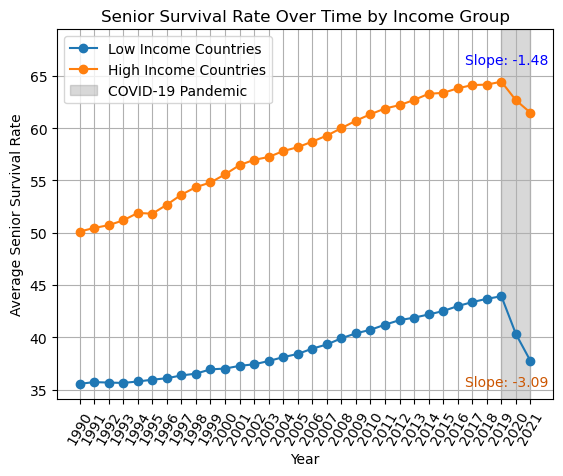

```python
#Group by Year and High_Income_Country and find mean Senior Survival rate
avg_by_group = hiyincomeadjusted.groupby(['Year', 'High_Income_Country'])['SeniorSurvival_All_MRValue'].mean().reset_index()

#make a pivot table
pivot_table = avg_by_group.pivot(index='Year', columns='High_Income_Country', values='SeniorSurvival_All_MRValue')

#Rename columns
pivot_table = pivot_table.rename(columns={0: 'Low Income Countries', 1: 'High Income Countries'})

#Plot the Data
plt.plot(pivot_table.index, pivot_table['Low Income Countries'], marker='o', label='Low Income Countries')
plt.plot(pivot_table.index, pivot_table['High Income Countries'], marker='o', label='High Income Countries')

plt.xlabel('Year')
plt.ylabel('Average Senior Survival Rate')
plt.title('Senior Survival Rate Over Time by Income Group')

plt.xticks(pivot_table.index, rotation=60)
plt.axvspan(2019, 2021, color='gray', alpha=0.3, label='COVID-19 Pandemic')
plt.ylim(bottom=None, top=pivot_table.max().max() + 5)


y_low = pivot_table.loc[2020, 'Low Income Countries']
y_high = pivot_table.loc[2020, 'High Income Countries']

plt.text(2016.5, y_low - 5, f"Slope: {slope_low:.2f}", color='#CC5500')
plt.text(2016.5, y_high + 3.5, f"Slope: {slope_high:.2f}", color='blue')

plt.legend()
plt.grid(True)
plt.show()
```

Question 2

Question: Which right (human right) as an aggregate had the highest rate of increase in the United States?

For this problem, I have decided to limit my scope and view the data from 2010 - 2021, since these were also that years that had the most consistent data collection, and also had the data for the metric we were observing. For this question, I looked at the indicators for the following rights:

- LMY_QofL_All_GBScore (Queality of Life)
- LMY_Education_All_GBScore (Education)
- LMY_Food_All_GBScore (Food)
- LMY_Health_All_GBScore (Health)
- LMY_Housing_All_GBScore (Housing)
- LMY_Work_All_GBScore (Work)

The GB score metric was used because it scored the rights aspect measured on the percentage of the global best benchmark, which was optimal in helping us understand the rate of increase in the United States. The data was collected from the Human Rights Measurement Initiative (HRMI) and was used to measure the rate of increase in the United States for each of these rights.

|  | Right | 2010 Score | 2021 Score | Average Change |
| --- | --- | --- | --- | --- |
| 0 | QofL | 92.053106 | 91.222925 | -0.075471 |
| 1 | Education | 84.384470 | 82.657524 | -0.156995 |
| 2 | Food | 98.579576 | 96.702546 | -0.170639 |
| 3 | Health | 81.936958 | 79.105428 | -0.257412 |
| 4 | Housing | 98.466726 | 99.052902 | 0.053289 |
| 5 | Work | 96.897798 | 98.596225 | 0.154402 |

[figure not shown]

```python
us_lmyglobalbest = lmyglobalbest[lmyglobalbest['Country'] == 'United States']

subset = us_lmyglobalbest[(us_lmyglobalbest['Year'] >= 2010) & (us_lmyglobalbest['Year'] <= 2021)]

rights = [
    'LMY_QofL_All_GBScore',
    'LMY_Education_All_GBScore',
    'LMY_Food_All_GBScore',
    'LMY_Health_All_GBScore',
    'LMY_Housing_All_GBScore',
    'LMY_Work_All_GBScore'
]

avg_changes = []
for r in rights:
    v_start = subset.loc[subset['Year'] == 2010, r].values[0]
    v_end = subset.loc[subset['Year'] == 2021, r].values[0]
    key = r.split('_')[1]
    slope = (v_end - v_start) / (2021 - 2010)
    avg_changes.append({
        'Right': r.split('_')[1],
        '2010 Score': v_start,
        '2021 Score': v_end,
        'Average Change': slope
    })

analysis_lmyglobalbest = pd.DataFrame(avg_changes)
display(analysis_lmyglobalbest)


plt.figure(figsize=(10, 6))
plt.bar(analysis_lmyglobalbest['Right'], analysis_lmyglobalbest['Average Change'], color='skyblue')
plt.xticks(rotation=45, ha='right')
plt.axhline(0, color='grey', linewidth=1, linestyle='--')  # zero line
plt.title('Average Change in Aggregate Right Scores in the US (1990-2021)')
plt.xlabel('Rights')
plt.ylabel('Average annual change (score/year)')
plt.xticks(rotation=45, ha='right')
plt.tight_layout()
plt.show()
```

Question 3

Question: Between 2018 and 2021, which 3 low and middle income countries had the highest change in education discrepancy between males and females?

Variables of Interest: LMY_Education_Female_IAScore and LMY_Education_Male_IAScore

```python
#import and clean csv file

sexdisaggregated_clean = sexdisaggregated.dropna(subset=['LMY_Education_Female_IAScore', 'HiY_Education_Female_IAScore'], how='all')


display(sexdisaggregated_clean.head(30))
```

|  | Country_Code | Country | High_Income_Country | Year | LMY_Education_Female_IAScore | LMY_Education_Female_GBScore | LMY_Education_Male_IAScore | LMY_Education_Male_GBScore | HiY_Education_Female_IAScore | HiY_Education_Female_GBScore | ... | NotLTUnemploy_Female_GBPenalty | NotLTUnemploy_Female_GBScore | NotLTUnemploy_Male_MRYear | NotLTUnemploy_Male_MRGDP | NotLTUnemploy_Male_IAFrontier | NotLTUnemploy_Male_MRValue | NotLTUnemploy_Male_IAPenalty | NotLTUnemploy_Male_IAScore | NotLTUnemploy_Male_GBPenalty | NotLTUnemploy_Male_GBScore |
| --- | --- | --- | --- | --- | --- | --- | --- | --- | --- | --- | --- | --- | --- | --- | --- | --- | --- | --- | --- | --- | --- |
| 91 | AGO | Angola | 0 | 2017 | 28.295244 | 26.516941 | 43.155140 | 41.156405 | NaN | NaN | ... | NaN | NaN | NaN | NaN | NaN | NaN | NaN | NaN | NaN | NaN |
| 92 | AGO | Angola | 0 | 2018 | 28.346761 | 26.508227 | 43.191265 | 41.134432 | NaN | NaN | ... | NaN | NaN | NaN | NaN | NaN | NaN | NaN | NaN | NaN | NaN |
| 93 | AGO | Angola | 0 | 2019 | 28.346761 | 26.508227 | 43.191265 | 41.134432 | NaN | NaN | ... | NaN | NaN | NaN | NaN | NaN | NaN | NaN | NaN | NaN | NaN |
| 94 | AGO | Angola | 0 | 2020 | 28.537092 | 26.508227 | 43.395993 | 41.134432 | NaN | NaN | ... | NaN | NaN | NaN | NaN | NaN | NaN | NaN | NaN | NaN | NaN |
| 115 | ALB | Albania | 0 | 2009 | NaN | NaN | NaN | NaN | 44.732700 | 33.518371 | ... | NaN | NaN | NaN | NaN | NaN | NaN | NaN | NaN | NaN | NaN |
| 116 | ALB | Albania | 0 | 2010 | 66.323247 | 60.233380 | 64.161224 | 59.441790 | 44.732700 | 33.518371 | ... | NaN | NaN | NaN | NaN | NaN | NaN | NaN | NaN | NaN | NaN |
| 117 | ALB | Albania | 0 | 2011 | 66.323247 | 60.233380 | 64.161224 | 59.441790 | 44.732700 | 33.518371 | ... | NaN | NaN | NaN | NaN | NaN | NaN | NaN | NaN | NaN | NaN |
| 119 | ALB | Albania | 0 | 2013 | 77.684497 | 72.676393 | 75.496736 | 71.978407 | 62.717861 | 53.870766 | ... | NaN | NaN | NaN | NaN | NaN | NaN | NaN | NaN | NaN | NaN |
| 120 | ALB | Albania | 0 | 2014 | 78.696314 | 73.738813 | 76.623567 | 73.159027 | 64.235587 | 55.464396 | ... | NaN | NaN | NaN | NaN | NaN | NaN | NaN | NaN | NaN | NaN |
| 121 | ALB | Albania | 0 | 2015 | NaN | NaN | NaN | NaN | 69.670749 | 59.356429 | ... | NaN | NaN | NaN | NaN | NaN | NaN | NaN | NaN | NaN | NaN |
| 122 | ALB | Albania | 0 | 2016 | NaN | NaN | NaN | NaN | 69.352004 | 59.037685 | ... | NaN | NaN | NaN | NaN | NaN | NaN | NaN | NaN | NaN | NaN |
| 123 | ALB | Albania | 0 | 2017 | NaN | NaN | NaN | NaN | 70.532344 | 60.218025 | ... | NaN | NaN | NaN | NaN | NaN | NaN | NaN | NaN | NaN | NaN |
| 124 | ALB | Albania | 0 | 2018 | NaN | NaN | NaN | NaN | 64.405803 | 57.259821 | ... | NaN | NaN | NaN | NaN | NaN | NaN | NaN | NaN | NaN | NaN |
| 125 | ALB | Albania | 0 | 2019 | NaN | NaN | NaN | NaN | 64.413991 | 57.268009 | ... | NaN | NaN | NaN | NaN | NaN | NaN | NaN | NaN | NaN | NaN |
| 126 | ALB | Albania | 0 | 2020 | 77.796242 | 72.669836 | 78.489445 | 74.072655 | 62.911073 | 55.765090 | ... | NaN | NaN | NaN | NaN | NaN | NaN | NaN | NaN | NaN | NaN |
| 127 | ALB | Albania | 0 | 2021 | 75.916022 | 70.789616 | 76.749654 | 72.332865 | 64.174586 | 57.028604 | ... | NaN | NaN | NaN | NaN | NaN | NaN | NaN | NaN | NaN | NaN |
| 186 | ARE | United Arab Emirates | 1 | 2016 | NaN | NaN | NaN | NaN | 56.085508 | 55.338332 | ... | NaN | NaN | NaN | NaN | NaN | NaN | NaN | NaN | NaN | NaN |
| 187 | ARE | United Arab Emirates | 1 | 2017 | NaN | NaN | NaN | NaN | 63.863571 | 63.116395 | ... | NaN | NaN | NaN | NaN | NaN | NaN | NaN | NaN | NaN | NaN |
| 188 | ARE | United Arab Emirates | 1 | 2018 | NaN | NaN | NaN | NaN | 64.077905 | 63.291598 | ... | NaN | NaN | NaN | NaN | NaN | NaN | NaN | NaN | NaN | NaN |
| 189 | ARE | United Arab Emirates | 1 | 2019 | NaN | NaN | NaN | NaN | 64.077905 | 63.291598 | ... | NaN | NaN | NaN | NaN | NaN | NaN | NaN | NaN | NaN | NaN |
| 190 | ARE | United Arab Emirates | 1 | 2020 | NaN | NaN | NaN | NaN | 64.077905 | 63.291598 | ... | NaN | NaN | NaN | NaN | NaN | NaN | NaN | NaN | NaN | NaN |
| 191 | ARE | United Arab Emirates | 1 | 2021 | NaN | NaN | NaN | NaN | 64.077905 | 63.291598 | ... | NaN | NaN | NaN | NaN | NaN | NaN | NaN | NaN | NaN | NaN |
| 217 | ARG | Argentina | 0 | 2015 | NaN | NaN | NaN | NaN | 61.554886 | 59.324015 | ... | NaN | NaN | NaN | NaN | NaN | NaN | NaN | NaN | NaN | NaN |
| 218 | ARG | Argentina | 0 | 2016 | NaN | NaN | NaN | NaN | 62.839951 | 60.609080 | ... | NaN | NaN | NaN | NaN | NaN | NaN | NaN | NaN | NaN | NaN |
| 219 | ARG | Argentina | 0 | 2017 | NaN | NaN | NaN | NaN | 62.485316 | 60.254445 | ... | NaN | NaN | NaN | NaN | NaN | NaN | NaN | NaN | NaN | NaN |
| 220 | ARG | Argentina | 0 | 2018 | NaN | NaN | NaN | NaN | 58.728756 | 56.912410 | ... | NaN | NaN | NaN | NaN | NaN | NaN | NaN | NaN | NaN | NaN |
| 221 | ARG | Argentina | 0 | 2019 | NaN | NaN | NaN | NaN | 59.505850 | 57.689504 | ... | NaN | NaN | NaN | NaN | NaN | NaN | NaN | NaN | NaN | NaN |
| 222 | ARG | Argentina | 0 | 2020 | NaN | NaN | NaN | NaN | 61.148640 | 59.332295 | ... | NaN | NaN | NaN | NaN | NaN | NaN | NaN | NaN | NaN | NaN |
| 223 | ARG | Argentina | 0 | 2021 | NaN | NaN | NaN | NaN | 61.148640 | 59.332295 | ... | NaN | NaN | NaN | NaN | NaN | NaN | NaN | NaN | NaN | NaN |
| 251 | ARM | Armenia | 0 | 2017 | 83.248321 | 77.125397 | 81.923514 | 76.158559 | NaN | NaN | ... | NaN | NaN | NaN | NaN | NaN | NaN | NaN | NaN | NaN | NaN |

30 rows × 216 columns

```python
#finding difference in education scores
sexdisaggregated_clean['diff_LMY'] = (
    sexdisaggregated_clean['LMY_Education_Male_IAScore']-
    sexdisaggregated_clean['LMY_Education_Female_IAScore']
).abs()

#dropping non LMY countries
sexdisaggregated_clean = sexdisaggregated_clean.dropna(subset=["diff_LMY"])

#dropping years that aren't 2018 or 2021
sexdisaggregated_sub = sexdisaggregated_clean[sexdisaggregated_clean['Year'].isin([2018, 2021])]

#shifting to a pivot table
diff_wide = (
    sexdisaggregated_sub
    .pivot_table(
        index=["Country_Code", "Country"],
        columns="Year",
        values="diff_LMY",
        aggfunc="first"
    )
)

#dropping NaNs and finding the difference between 2021 and 2018 discrepancy for each country
diff_wide = diff_wide.dropna(subset=[2018, 2021])
diff_wide["diff"] = diff_wide[2021] - diff_wide[2018]

#finding the top 3 differences
top3 = diff_wide["diff"].nlargest(3)
print(top3)

display(sexdisaggregated_sub.head(30))
display(diff_wide)
```

```
Country_Code  Country
FSM           Micronesia, Fed. Sts.    5.531224
WSM           Samoa                    4.085374
PLW           Palau                    3.430838
Name: diff, dtype: float64
```

|  | Country_Code | Country | High_Income_Country | Year | LMY_Education_Female_IAScore | LMY_Education_Female_GBScore | LMY_Education_Male_IAScore | LMY_Education_Male_GBScore | HiY_Education_Female_IAScore | HiY_Education_Female_GBScore | ... | NotLTUnemploy_Female_GBScore | NotLTUnemploy_Male_MRYear | NotLTUnemploy_Male_MRGDP | NotLTUnemploy_Male_IAFrontier | NotLTUnemploy_Male_MRValue | NotLTUnemploy_Male_IAPenalty | NotLTUnemploy_Male_IAScore | NotLTUnemploy_Male_GBPenalty | NotLTUnemploy_Male_GBScore | diff_LMY |
| --- | --- | --- | --- | --- | --- | --- | --- | --- | --- | --- | --- | --- | --- | --- | --- | --- | --- | --- | --- | --- | --- |
| 92 | AGO | Angola | 0 | 2018 | 28.346761 | 26.508227 | 43.191265 | 41.134432 | NaN | NaN | ... | NaN | NaN | NaN | NaN | NaN | NaN | NaN | NaN | NaN | 14.844503 |
| 127 | ALB | Albania | 0 | 2021 | 75.916022 | 70.789616 | 76.749654 | 72.332865 | 64.174586 | 57.028604 | ... | NaN | NaN | NaN | NaN | NaN | NaN | NaN | NaN | NaN | 0.833632 |
| 252 | ARM | Armenia | 0 | 2018 | 82.926081 | 77.093043 | 81.592269 | 76.106305 | NaN | NaN | ... | NaN | NaN | NaN | NaN | NaN | NaN | NaN | NaN | NaN | 1.333812 |
| 255 | ARM | Armenia | 0 | 2021 | 79.347728 | 74.129402 | 79.285875 | 74.391554 | NaN | NaN | ... | NaN | NaN | NaN | NaN | NaN | NaN | NaN | NaN | NaN | 0.061853 |
| 316 | ATG | Antigua and Barbuda | 1 | 2018 | 77.391919 | 75.213673 | 69.047786 | 67.165340 | NaN | NaN | ... | NaN | NaN | NaN | NaN | NaN | NaN | NaN | NaN | NaN | 8.344133 |
| 319 | ATG | Antigua and Barbuda | 1 | 2021 | 79.599388 | 76.626624 | 71.785888 | 69.332446 | NaN | NaN | ... | NaN | NaN | NaN | NaN | NaN | NaN | NaN | NaN | NaN | 7.813500 |
| 348 | AUS | Australia | 1 | 2018 | 92.765373 | 90.441777 | 88.603675 | 86.364732 | 83.216851 | 81.275154 | ... | 67.091884 | 2018.0 | 49085.93337 | 99.150489 | 81.363706 | 8.642373 | 70.468982 | 8.898135 | 69.431756 | 4.161697 |
| 351 | AUS | Australia | 1 | 2021 | 92.391218 | 90.137489 | 88.064986 | 85.891255 | 84.631302 | 82.689605 | ... | 67.091884 | 2018.0 | 49085.93337 | 99.150489 | 81.363706 | 8.642373 | 70.468982 | 8.898135 | 69.431756 | 4.326232 |
| 380 | AUT | Austria | 1 | 2018 | 87.517591 | 85.487086 | 86.865475 | 84.819678 | 78.115179 | 76.416658 | ... | 52.507704 | 2018.0 | 55217.28653 | 99.248365 | 70.966865 | 14.022180 | 52.802404 | 14.167388 | 52.073153 | 0.652115 |
| 383 | AUT | Austria | 1 | 2021 | 87.047383 | 85.026566 | 85.893328 | 83.910331 | 79.015994 | 77.317473 | ... | 51.288404 | 2021.0 | 53817.30626 | 99.228057 | 67.060392 | 14.602854 | 47.654100 | 14.711351 | 46.986779 | 1.154054 |
| 415 | AZE | Azerbaijan | 0 | 2021 | 72.892869 | 68.760924 | 71.887325 | 68.017964 | NaN | NaN | ... | NaN | NaN | NaN | NaN | NaN | NaN | NaN | NaN | NaN | 1.005544 |
| 444 | BDI | Burundi | 0 | 2018 | 100.000000 | 58.005256 | 99.938200 | 53.248819 | NaN | NaN | ... | NaN | NaN | NaN | NaN | NaN | NaN | NaN | NaN | NaN | 0.061800 |
| 447 | BDI | Burundi | 0 | 2021 | 100.000000 | 56.478266 | 98.910551 | 51.686286 | NaN | NaN | ... | NaN | NaN | NaN | NaN | NaN | NaN | NaN | NaN | NaN | 1.089449 |
| 476 | BEL | Belgium | 1 | 2018 | 90.920908 | 88.794227 | 91.356698 | 89.193039 | 86.400942 | 84.425382 | ... | 31.313336 | 2018.0 | 51113.48174 | 99.185560 | 49.140820 | 15.319658 | 25.932428 | 15.302395 | 25.559024 | 0.435790 |
| 479 | BEL | Belgium | 1 | 2021 | 90.619381 | 88.404926 | 90.558873 | 88.357865 | 86.268818 | 84.293258 | ... | 35.033608 | 2021.0 | 52174.90682 | 99.202789 | 57.846476 | 15.512730 | 35.948586 | 15.547590 | 35.436684 | 0.060508 |
| 508 | BEN | Benin | 0 | 2018 | 63.958342 | 50.350879 | 74.741271 | 59.233134 | NaN | NaN | ... | NaN | NaN | NaN | NaN | NaN | NaN | NaN | NaN | NaN | 10.782929 |
| 511 | BEN | Benin | 0 | 2021 | 59.699595 | 47.456850 | 66.329594 | 53.335620 | NaN | NaN | ... | NaN | NaN | NaN | NaN | NaN | NaN | NaN | NaN | NaN | 6.629999 |
| 540 | BFA | Burkina Faso | 0 | 2018 | 67.917423 | 46.654999 | 70.689638 | 48.287798 | NaN | NaN | ... | NaN | NaN | NaN | NaN | NaN | NaN | NaN | NaN | NaN | 2.772215 |
| 543 | BFA | Burkina Faso | 0 | 2021 | 66.038847 | 45.270891 | 66.050423 | 44.736942 | NaN | NaN | ... | NaN | NaN | NaN | NaN | NaN | NaN | NaN | NaN | NaN | 0.011576 |
| 572 | BGD | Bangladesh | 0 | 2018 | 66.004042 | 57.954277 | 62.265713 | 54.656737 | NaN | NaN | ... | NaN | NaN | NaN | NaN | NaN | NaN | NaN | NaN | NaN | 3.738329 |
| 604 | BGR | Bulgaria | 0 | 2018 | 78.614791 | 74.095923 | 78.033289 | 73.874975 | 59.989868 | 56.199460 | ... | 34.117832 | 2018.0 | 22196.01959 | 98.019412 | 39.645775 | 0.160584 | 30.363046 | 0.159958 | 29.660710 | 0.581503 |
| 607 | BGR | Bulgaria | 0 | 2021 | 64.359767 | 61.080239 | 63.497206 | 60.637076 | 59.251164 | 55.460755 | ... | 41.616345 | 2021.0 | 24386.17980 | 98.213183 | 49.882696 | 1.877926 | 40.731431 | 1.883130 | 39.840935 | 0.862560 |
| 636 | BHR | Bahrain | 1 | 2018 | 81.780790 | 80.043966 | 74.048716 | 72.686310 | NaN | NaN | ... | NaN | NaN | NaN | NaN | NaN | NaN | NaN | NaN | NaN | 7.732074 |
| 639 | BHR | Bahrain | 1 | 2021 | 80.693403 | 78.923203 | 72.979008 | 71.590421 | NaN | NaN | ... | NaN | NaN | NaN | NaN | NaN | NaN | NaN | NaN | NaN | 7.714395 |
| 700 | BIH | Bosnia and Herzegovina | 0 | 2018 | 75.796524 | 70.469240 | 75.795502 | 70.435619 | 56.331909 | 51.846298 | ... | NaN | NaN | NaN | NaN | NaN | NaN | NaN | NaN | NaN | 0.001022 |
| 703 | BIH | Bosnia and Herzegovina | 0 | 2021 | 63.875055 | 59.941133 | 61.446277 | 57.811459 | 52.784354 | 48.298743 | ... | NaN | NaN | NaN | NaN | NaN | NaN | NaN | NaN | NaN | 2.428778 |
| 735 | BLR | Belarus | 0 | 2021 | 80.711383 | 75.931024 | 82.689902 | 78.019126 | 77.999454 | 70.765551 | ... | NaN | NaN | NaN | NaN | NaN | NaN | NaN | NaN | NaN | 1.978520 |
| 860 | BRA | Brazil | 0 | 2018 | 73.362620 | 69.837287 | 72.304718 | 68.806957 | 58.845275 | 54.039690 | ... | NaN | NaN | NaN | NaN | NaN | NaN | NaN | NaN | NaN | 1.057902 |
| 863 | BRA | Brazil | 0 | 2021 | 75.379790 | 71.475070 | 73.391786 | 69.691546 | 61.718619 | 56.913034 | ... | NaN | NaN | NaN | NaN | NaN | NaN | NaN | NaN | NaN | 1.988004 |
| 927 | BRN | Brunei Darussalam | 1 | 2021 | 62.173189 | 60.991841 | 56.854542 | 55.795692 | 38.568458 | 37.756293 | ... | NaN | NaN | NaN | NaN | NaN | NaN | NaN | NaN | NaN | 5.318647 |

30 rows × 217 columns

| Country_Code | Year Country | 2018 | 2021 | diff |
| --- | --- | --- | --- | --- |
| ARM | Armenia | 1.333812 | 0.061853 | -1.271960 |
| ATG | Antigua and Barbuda | 8.344133 | 7.813500 | -0.530633 |
| AUS | Australia | 4.161697 | 4.326232 | 0.164534 |
| AUT | Austria | 0.652115 | 1.154054 | 0.501939 |
| BDI | Burundi | 0.061800 | 1.089449 | 1.027648 |
| ... | ... | ... | ... | ... |
| URY | Uruguay | 2.810075 | 2.837314 | 0.027239 |
| USA | United States | 0.166959 | 1.535835 | 1.368876 |
| VUT | Vanuatu | 0.823190 | 3.026627 | 2.203437 |
| WSM | Samoa | 7.121939 | 11.207313 | 4.085374 |
| ZAF | South Africa | 8.436193 | 7.651940 | -0.784253 |

115 rows × 3 columns

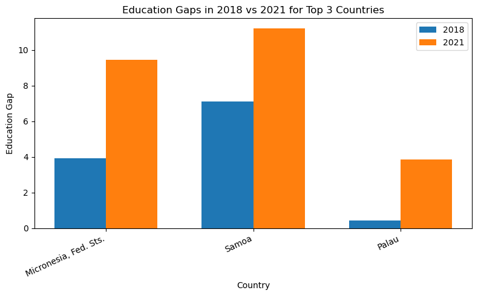

```python
#visual 1

top3_codes = top3.index

#get data from top3 rows for 2018 and 2021
sub = diff_wide.loc[top3_codes, [2018, 2021]]

#country names for x axis labels
countries = sub.index.get_level_values("Country")


x     = np.arange(len(countries))   # [0, 1, 2]
width = 0.35

plt.figure(figsize=(8, 5))


plt.bar(x - width/2, sub[2018].values, width, label="2018")
plt.bar(x + width/2, sub[2021].values, width, label="2021")


plt.xticks(x, countries, rotation=25, ha="right")
plt.xlabel("Country")
plt.ylabel("Education Gap")
plt.title("Education Gaps in 2018 vs 2021 for Top 3 Countries")
plt.legend()

plt.tight_layout()
plt.show()
```

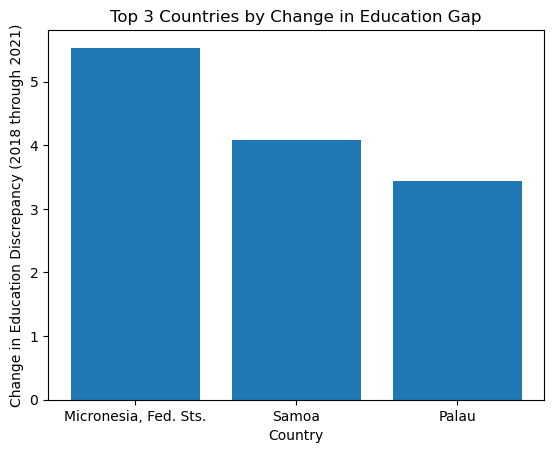

```python
#visual 2


labels = top3.index.get_level_values("Country")
heights = top3.values

plt.bar(labels, heights)
plt.xlabel("Country")
plt.ylabel("Change in Education Discrepancy (2018 through 2021)")
plt.title("Top 3 Countries by Change in Education Gap")
plt.show()
```